# Impact of severe wheather events on public health and ecomomy in the US

Sebastien Plat

21 février 2016

## Synopsis

Storms and other **severe weather events** can cause both **public health and economic problems** for communities and municipalities. Many severe events can result in fatalities, injuries, and property damage. Preventing such outcomes to the extent possible is a key concern.

This document will present the analysis of the U.S. National Oceanic and Atmospheric Administration’s (NOAA) Storm Database, and its results regarding the following questions:

- Across the US, which types of events are **most harmful** with respect to population health?
- Across the US, which types of events have the **greatest economic consequences**?

The answer will show:

- the **Top10 Event Types** for **fatalities and injuries, property damage and crop damage**
- their **average impact** when harmful

The average impact will facilitate the **comparizon between Event Types with very different frequencies**.

## Loading Data

We start by downloading the data & reading it:

```r
# download archive
if (!dir.exists("data")) {
  dir.create("data")
}

if (!file.exists("data\\stormData.bz2")) {
  download.file("https://d396qusza40orc.cloudfront.net/repdata%2Fdata%2FStormData.csv.bz2",
                "data\\stormData.bz2")
}

# read archive (takes a while)
storm <- read.csv("data\\stormData.bz2")
```

A brief look at the data frame shows more than 900k observations and 37 variables.

```r
# first look at data
str(storm)
```

```
## 'data.frame':    902297 obs. of  37 variables:
##  $ STATE__   : num  1 1 1 1 1 1 1 1 1 1 ...
##  $ BGN_DATE  : Factor w/ 16335 levels "1/1/1966 0:00:00",..: 6523 6523 4242 11116 2224 2224 2260 383 3980 3980 ...
##  $ BGN_TIME  : Factor w/ 3608 levels "00:00:00 AM",..: 272 287 2705 1683 2584 3186 242 1683 3186 3186 ...
##  $ TIME_ZONE : Factor w/ 22 levels "ADT","AKS","AST",..: 7 7 7 7 7 7 7 7 7 7 ...
##  $ COUNTY    : num  97 3 57 89 43 77 9 123 125 57 ...
##  $ COUNTYNAME: Factor w/ 29601 levels "","5NM E OF MACKINAC BRIDGE TO PRESQUE ISLE LT MI",..: 13513 1873 4598 10592 4372 10094 1973 23873 24418 4598 ...
##  $ STATE     : Factor w/ 72 levels "AK","AL","AM",..: 2 2 2 2 2 2 2 2 2 2 ...
##  $ EVTYPE    : Factor w/ 985 levels "   HIGH SURF ADVISORY",..: 834 834 834 834 834 834 834 834 834 834 ...
##  $ BGN_RANGE : num  0 0 0 0 0 0 0 0 0 0 ...
##  $ BGN_AZI   : Factor w/ 35 levels "","  N"," NW",..: 1 1 1 1 1 1 1 1 1 1 ...
##  $ BGN_LOCATI: Factor w/ 54429 levels "","- 1 N Albion",..: 1 1 1 1 1 1 1 1 1 1 ...
##  $ END_DATE  : Factor w/ 6663 levels "","1/1/1993 0:00:00",..: 1 1 1 1 1 1 1 1 1 1 ...
##  $ END_TIME  : Factor w/ 3647 levels ""," 0900CST",..: 1 1 1 1 1 1 1 1 1 1 ...
##  $ COUNTY_END: num  0 0 0 0 0 0 0 0 0 0 ...
```

[output cut: 23 more lines]

# Data Processing

We want to keep only the observations and variables that are relevant for this analysis: event type, fatalities and damage.

By looking at the documentation ([link](https://d396qusza40orc.cloudfront.net/repdata%2Fpeer2_doc%2Fpd01016005curr.pdf)), and especially section 2.7 p12, we can see there are two types of damage: property & crop. They are expressed with two variables:

- DMP gives the amount
- EXP gives the unit: thousands (K), millions (M) or billions (B)

This leads us to select only the following variables:

```r
# creating a year variable
storm$year <- factor(as.POSIXlt(strptime(as.character(storm$BGN_DATE), "%m/%d/%Y"))$year+1900)

# selecting fields relevant to the analysis
stormSelect <- select (storm, BGN_DATE, STATE, EVTYPE, FATALITIES, INJURIES, PROPDMG, PROPDMGEXP, CROPDMG, CROPDMGEXP, year)
```

## Cleaning damage costs

Table 1 and Table 2 show that **the damage unit is not always properly mentioned**: we expect only K, M and B (see above).

```r
# units for property damages > 0 - expecting only K,M,B
t <- table (stormSelect[stormSelect$PROPDMG > 0, ]$PROPDMGEXP)
pandoc.table(t, split.table = Inf, caption = "Table 1: Units for Property damage",
             emphasize.strong.cols = which(toupper(names(t)) %in% c("B","K","M")))
```

Table 1: Units for Property damage

|  | - | ? | + | 0 | 1 | 2 | 3 | 4 | 5 | 6 | 7 | 8 | B | h | H | K | m | M |
| --- | --- | --- | --- | --- | --- | --- | --- | --- | --- | --- | --- | --- | --- | --- | --- | --- | --- | --- |
| 76 | 1 | 0 | 5 | 209 | 0 | 1 | 1 | 4 | 18 | 3 | 2 | 0 | **40** | 1 | 6 | **227,481** | **7** | **11,319** |

```r
# units for crop damages > 0 - expecting only K,M,B
t <- table (stormSelect[stormSelect$CROPDMG > 0, ]$CROPDMGEXP)
pandoc.table(t, split.table = Inf, caption = "Table 2: Units for Crop damage",
             emphasize.strong.cols = which(toupper(names(t)) %in% c("B","K","M")))
```

Table 2: Units for Crop damage

|  | ? | 0 | 2 | B | k | K | m | M |
| --- | --- | --- | --- | --- | --- | --- | --- | --- |
| 3 | 0 | 12 | 0 | **7** | **21** | **20,137** | **1** | **1,918** |

To adress this issue, we will:

- consider **entries with incorrect damage units as having zero damage**
- create new variables **prop_dmg** and **crop_dmg** that convert damages in USD

```r
# cleaning up property damages: we count them only if they have a proper unit
stormSelect <- mutate (stormSelect, prop_dmg = ifelse(PROPDMGEXP == "b" | PROPDMGEXP == "B", PROPDMG*10^9,
                                               ifelse(PROPDMGEXP == "m" | PROPDMGEXP == "M", PROPDMG*10^6,
                                               ifelse(PROPDMGEXP == "k" | PROPDMGEXP == "K", PROPDMG*10^3, 0))))

# cleaning up crop damages: we count them only if they have a proper unit
stormSelect <- mutate (stormSelect, crop_dmg = ifelse(CROPDMGEXP == "b" | CROPDMGEXP == "B", CROPDMG*10^9,
                                               ifelse(CROPDMGEXP == "m" | CROPDMGEXP == "M", CROPDMG*10^6,
                                               ifelse(CROPDMGEXP == "k" | CROPDMGEXP == "K", CROPDMG*10^3, 0))))
```

## Filtering Data

We will keep **only the observations with either casualties or damage**:

```r
# we drop all events that have neither fatalities/injuries nor damages
stormSelectFilter <- filter (stormSelect, FATALITIES > 0 |
                                          INJURIES > 0 |
                                          prop_dmg > 0 |
                                          crop_dmg > 0) %>%
                     select (BGN_DATE, STATE, EVTYPE,
                             FATALITIES, INJURIES,
                             PROPDMG, PROPDMGEXP,  prop_dmg,
                             CROPDMG, CROPDMGEXP, crop_dmg,
                             year)

# we drop all unsued levels
stormSelectFilter <- droplevels (stormSelectFilter)

# we convert all EVTYPE levels in uppercase
levels(stormSelectFilter$EVTYPE) <- toupper(levels(stormSelectFilter$EVTYPE))
```

As shown below, our data frame is now much smaller, with only 250k observations:

```r
dim (stormSelectFilter)
```

```
## [1] 254325     12
```

## Cleaning outliers

Fig. 1 shows the fatalities and damage reported for each recorded event:

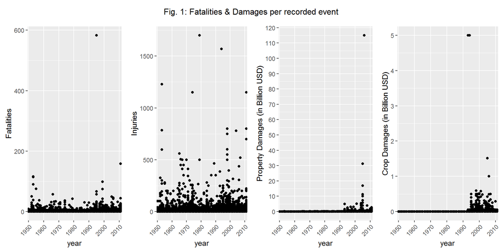

```r
# fatalities
p1 = qplot(data=stormSelectFilter, x=year, y = FATALITIES)
p1 = p1 + theme(axis.text.x = element_text(angle = 45, vjust = 1, hjust=1))
p1 = p1 + scale_x_discrete(breaks = seq(1950, 2010, 10))
p1 = p1 + ylab("Fatalities")

# injuries
p2 = qplot(data=stormSelectFilter, x=year, y = INJURIES)
p2 = p2 + theme(axis.text.x = element_text(angle = 45, vjust = 1, hjust=1))
p2 = p2 + scale_x_discrete(breaks = seq(1950, 2010, 10))
p2 = p2 + ylab("Injuries")

# property damages
p3 = qplot(data=stormSelectFilter, x=year, y=prop_dmg) + geom_point()
p3 = p3 + theme(axis.text.x = element_text(angle = 45, vjust = 1, hjust=1))
p3 = p3 + scale_x_discrete(breaks = seq(1950, 2010, 10))
p3 = p3 + scale_y_continuous(breaks = seq(0, 1.2*10^11, 10^10), labels = seq(0,120,10))
p3 = p3 + ylab("Property Damages (in Billion USD)")

# crop damages
p4 = qplot(data=stormSelectFilter, x=year, y=crop_dmg) + geom_point()
p4 = p4 + theme(axis.text.x = element_text(angle = 45, vjust = 1, hjust=1))
p4 = p4 + scale_x_discrete(breaks = seq(1950, 2010, 10))
p4 = p4 + scale_y_continuous(breaks = seq(0, 5*10^9, 10^9), labels = seq(0,5,1))
p4 = p4 + ylab("Crop Damages (in Billion USD)")

multiplot(p1,p2,p3,p4,cols=4, title = "Fig. 1: Fatalities & Damages per recorded event")
```

We clearly see some outliers. Let’s investigate them.

### Fatalities

```r
# fatalities
pandoc.table(stormSelectFilter[which(stormSelectFilter$FATALITIES > 200),
                               c("BGN_DATE", "STATE", "EVTYPE", "FATALITIES")], split.table = Inf)
```

|  | BGN_DATE | STATE | EVTYPE | FATALITIES |
| --- | --- | --- | --- | --- |
| **31915** | 7/12/1995 0:00:00 | IL | HEAT | 583 |

The **deadliest** recorded event is the **July 1995 Heat Wave in Chicago** ([link](https://en.wikipedia.org/wiki/1995_Chicago_heat_wave)).

### Injuries

```r
# fatalities
pandoc.table(stormSelectFilter[which(stormSelectFilter$INJURIES > 1000),
                               c("BGN_DATE", "STATE", "EVTYPE", "INJURIES")], split.table = Inf)
```

|  | BGN_DATE | STATE | EVTYPE | INJURIES |
| --- | --- | --- | --- | --- |
| **11611** | 6/9/1953 0:00:00 | MA | TORNADO | 1,228 |
| **18631** | 4/3/1974 0:00:00 | OH | TORNADO | 1,150 |
| **24585** | 4/10/1979 0:00:00 | TX | TORNADO | 1,700 |
| **43962** | 2/8/1994 0:00:00 | OH | ICE STORM | 1,568 |
| **241460** | 5/22/2011 0:00:00 | MO | TORNADO | 1,150 |

The recorded events with the most injuries are:

- the **1953 Flint-Worcester tornado outbreak sequence** ([link](https://en.wikipedia.org/wiki/Flint%E2%80%93Worcester_tornado_outbreak_sequence))
- the **1974 Super Outbreak** ([link](https://en.wikipedia.org/wiki/1974_Super_Outbreak))
- the **1979 Red River Valley tornado outbreak** ([link](https://en.wikipedia.org/wiki/1979_Red_River_Valley_tornado_outbreak))
- the **1994 Artic Outbreak** ([link](https://shaneholinde.wordpress.com/2014/01/07/remembering-januaryfebruary-1994-winters-tko/))
- the **2011 tornado outbreak** ([link](https://en.wikipedia.org/wiki/May_21%E2%80%9326,_2011_tornado_outbreak_sequence))

### Property Damages

```r
# property damage
pandoc.table(stormSelectFilter[which(stormSelectFilter$prop_dmg >= 10*10^9),
                               c("BGN_DATE", "STATE", "EVTYPE", "PROPDMG", "PROPDMGEXP")], split.table = Inf)
```

|  | BGN_DATE | STATE | EVTYPE | PROPDMG | PROPDMGEXP |
| --- | --- | --- | --- | --- | --- |
| **153302** | 10/24/2005 0:00:00 | FL | HURRICANE/TYPHOON | 10 | B |
| **155490** | 8/28/2005 0:00:00 | LA | HURRICANE/TYPHOON | 16.93 | B |
| **155491** | 8/29/2005 0:00:00 | LA | STORM SURGE | 31.3 | B |
| **156656** | 8/29/2005 0:00:00 | MS | STORM SURGE | 11.26 | B |
| **162532** | 1/1/2006 0:00:00 | CA | FLOOD | 115 | B |

The most costly events (**property damage**) are:

- **Hurricane Katrina in 2005** ([link](https://en.wikipedia.org/wiki/Hurricane_Katrina)), identified as the costliest natural disaster in the History of the USA
- the **flood of january 2006 in California**

We will convert the damage as being **115 millions USD** instead:

```r
# converting billions to millions for the CA flood of 2006
stormSelectFilter[which(stormSelectFilter$prop_dmg > 10^11),]$PROPDMGEXP <- "M"
stormSelectFilter[which(stormSelectFilter$prop_dmg > 10^11),]$prop_dmg <- 115*10^6
```

### Crop Damages

```r
# crop damage
pandoc.table(stormSelectFilter[which(stormSelectFilter$crop_dmg >= 10^9),
                               c("BGN_DATE", "STATE", "EVTYPE", "CROPDMG", "CROPDMGEXP")], split.table = Inf)
```

|  | BGN_DATE | STATE | EVTYPE | CROPDMG | CROPDMGEXP |
| --- | --- | --- | --- | --- | --- |
| **31770** | 8/31/1993 0:00:00 | IL | RIVER FLOOD | 5 | B |
| **37985** | 2/9/1994 0:00:00 | MS | ICE STORM | 5 | B |
| **156657** | 8/29/2005 0:00:00 | MS | HURRICANE/TYPHOON | 1.51 | B |
| **171518** | 1/1/2006 0:00:00 | TX | DROUGHT | 1 | B |

The most costly events (**crop damage**) are:

- the **Great Flood of 1993** ([link](https://en.wikipedia.org/wiki/Great_Flood_of_1993))
- the **Southeast Ice Storm of 1994** ([link](http://www.alabamawx.com/?p=5469))
- **Hurricane Katrina in 2005**
- a **severe drought in Texas in 2005-2006** ([link](http://twri.tamu.edu/publications/txh2o/fall-2011/timeline-of-droughts-in-texas/))

## Cleaning Event Types

The documentation stipulates that there are **48 Event Types** one can use to describe an event (section 7 - Event Types, p18). The events are largely reported in this normalized fashion, but there are also many cases where the guidelines are not fully respected.

In an attempt to facilitate the reading of the results, we will **map all the events to the 48 Event Types** by using keywords and the following rules:

- the **more precise classification** is listed **first** (“marine thunderstorm” before “thunderstorm”, etc.)
- the **deadliest / costliest events** are listed **first**, to catch events that could be affected to different Event Types (“Avalanche + Blizzard”" for example)
- the few events without a clear Event Type will be **classified as “OTHER”**

The resulting classification, as well as the details of the “decodeList” function, are listed in the Appendix.

```r
# EVTYPE list: EVTYPE levels (only 430 rows, much faster than working with the full table)
EVTYPE_list <- data.frame(EVTYPE=levels(stormSelectFilter$EVTYPE))

# normalizing event types using the Storm Data Event Table
EVTYPE_list$Event_Type <- decodeList (EVTYPE_list$EVTYPE, "OTHER", list(
                                      c("ASTRONOMICAL LOW TIDE"), "ASTRONOMICAL LOW TIDE",
                                      c("AVALANCHE", "AVALANCE"), "AVALANCHE",
                                      c("BLIZZARD"), "BLIZZARD",
                                      c("COASTAL FLOOD", "COASTAL  FLOOD"), "COASTAL FLOOD",
                                      c("LAKESHORE FLOOD"), "LAKESHORE FLOOD",
                                      c("TORNADO", "TORNDAO"), "TORNADO",
                                      c("TSUNAMI"), "TSUNAMI",
                                      c("HURRICANE", "TYPHOON"), "HURRICANE/TYPHOON",
                                      c("WATERSPOUT"), "WATERSPOUT",
                                      c("STORM SURGE","STORM TIDE"), "STORM SURGE/TIDE",
                                      c("MARINE THUNDESRSTORM", "MARINE TSTM"), "MARINE THUNDERSTORM WIND",
                                      c("TSTM", "TUNDERSTORM", "THUNDERSTORM", "THUDERSTORM", "THUNDERTORM", "THUNERSTORM", "THUNDERESTORM", "THUNDEERSTORM", "THUNDERSTROM"), "THUNDERSTORM WIND",
                                      c("ICE STORM"), "ICE STORM",
                                      c("WINTER STORM"), "WINTER STORM",
                                      c("WINTER WEATHER"), "WINTER WEATHER",
                                      c("TROPICAL STORM"), "TROPICAL STORM",
                                      c("TROPICAL DEPRESSION"), "TROPICAL DEPRESSION",
                                      c("LANDSLIDE"), "LANDSLIDE",
                                      c("DUST DEVIL"), "DUST DEVIL",
                                      c("DUST STORM"), "DUST STORM",
                                      c("DROUGHT"), "DROUGHT",
                                      c("EXCESSIVE HEAT", "EXTREME HEAT", "RECORD HEAT", "UNSEASONABLY WARM"), "EXCESSIVE HEAT",
                                      c("HEAT"), "HEAT",
                                      c("EXTREME COLD", "RECORD COLD", "EXTREME WINDCHILL", "UNSEASONABLY COLD", "UNSEASONABLE COLD"), "EXTREME COLD/WIND CHILL",
                                      c("COLD", "LOW TEMPERATURE"), "COLD/WIND CHILL",
                                      c("FLASH FLOOD", "FLASHFLOOD"), "FLASH FLOOD",
                                      c("FLOOD", "FLD"), "FLOOD",
                                      c("MARINE HIGH WIND"), "MARINE HIGH WIND",
                                      c("HIGH WIND"), "HIGH WIND",
                                      c("MARINE HAIL"), "MARINE HAIL",
                                      c("HAIL"), "HAIL",
                                      c("HIGH SURF", "HEAVY SURF"), "HIGH SURF",
                                      c("RIP CURRENT"), "RIP CURRENT",
                                      c("SLEET"), "SLEET",
                                      c("LIGHTNING", "LIGHTING", "LIGNTNING"), "LIGHTNING",
                                      c("MARINE STRONG WIND"), "MARINE STRONG WIND",
                                      c("STRONG WIND"), "STRONG WIND",
                                      c("WINTER STORM"), "WINTER STORM",
                                      c("FROST", "FREEZE"), "FROST/FREEZE",
                                      c("HEAVY SNOW", "EXCESSIVE SNOW"), "HEAVY SNOW",
                                      c("LAKE-EFFECT SNOW"), "LAKE-EFFECT SNOW",
                                      c("FREEZING FOG"), "FREZZING FOG",
                                      c("FOG"), "DENSE FOG",
                                      c("HEAVY RAIN"), "HEAVY RAIN",
                                      c("DEBRIS FLOW"), "DEBRIS FLOW",
                                      c("DENSE SMOKE"), "DENSE SMOKE",
                                      c("FUNNEL CLOUD"), "FUNNEL CLOUD",
                                      c("SEICHE"), "SEICHE",
                                      c("VOLCANIC ASH"), "VOLCANIC ASH",
                                      c("WILDFIRE", "WILD/FOREST FIRE", "WILD FIRES", "WILDFIRES", "FOREST FIRES"), "WILDFIRE"))

# merging the Event Type list with the main dataset
stormSelectFilterGroup <- left_join(stormSelectFilter, EVTYPE_list, by="EVTYPE")

# converting values into factors
stormSelectFilterGroup$Event_Type <- factor(stormSelectFilterGroup$Event_Type)
```

# Results

Now that our Data Processing is complete, we can focus on our two questions:

- Across the US, which types of events are most harmful with respect to population health?
- Across the US, which types of events have the greatest economic consequences?

Table 3 to 6 show the Top 10 Event Types for the four paramaters we are interested in: Fatalities, Injuries, Property Damage & Crop Damage. Are included:

- the number of recorded events with parameter > 0
- the total for the period 1950-2011
- the average for events with parameter > 0

## Fatalities

```r
# group by event type
stormFatalities <- as.data.frame(group_by(stormSelectFilterGroup, Event_Type) %>%
                                 summarize(countDeadly = length(which(FATALITIES > 0)),
                                           Fatalities=sum(FATALITIES)))

# identify top 10
stormFatalities <- arrange(stormFatalities,desc(Fatalities))
stormFatalities$Top10 <- ifelse(row(stormFatalities)<10,as.character(stormFatalities$Event_Type), "OTHER")[,1]

# group the other event types as "OTHER"
stormFatalitiesFinal <- as.data.frame(group_by(stormFatalities, Top10) %>%
                                      summarize(deadlyEvents = sum(countDeadly),
                                                Fatalities=sum(Fatalities))) %>%
                                      arrange(desc(Fatalities))

# estimate avg when fatalities
stormFatalitiesFinal$Average <- round(with(stormFatalitiesFinal, Fatalities/deadlyEvents),1)

# move "OTHER" at the end
stormFatalitiesFinal <- rbind (stormFatalitiesFinal[-which(stormFatalitiesFinal$Top10=="OTHER"), ],
                               stormFatalitiesFinal[which(stormFatalitiesFinal$Top10=="OTHER"), ])
rownames(stormFatalitiesFinal) <- NULL

# sort factors by decr fatalities
stormFatalitiesFinal$Top10 <- with(stormFatalitiesFinal, factor(Top10, levels=Top10[1:10]))

pandoc.table(stormFatalitiesFinal, split.table = Inf, justify="right",
             caption = "Table 3: Fatalities per Event Type - Total & Average",
             emphasize.strong.rows = which(stormFatalitiesFinal$Average > 3,  arr.ind = TRUE))
```

Table 3: Fatalities per Event Type - Total & Average

| Top10 | deadlyEvents | Fatalities | Average |
| --- | --- | --- | --- |
| **TORNADO** | **1,604** | **5,661** | **3.5** |
| **EXCESSIVE HEAT** | **591** | **2,058** | **3.5** |
| **HEAT** | **205** | **1,114** | **5.4** |
| FLASH FLOOD | 671 | 1,035 | 1.5 |
| LIGHTNING | 760 | 817 | 1.1 |
| THUNDERSTORM WIND | 585 | 721 | 1.2 |
| RIP CURRENT | 508 | 572 | 1.1 |
| FLOOD | 333 | 512 | 1.5 |
| EXTREME COLD/WIND CHILL | 212 | 307 | 1.4 |
| OTHER | 1,505 | 2,348 | 1.6 |

## Injuries

```r
# group by event type
stormInjuries <- as.data.frame(group_by(stormSelectFilterGroup, Event_Type) %>%
                                 summarize(countHarmful = length(which(INJURIES > 0)),
                                           Injuries=sum(INJURIES)))

# identify top 10
stormInjuries <- arrange(stormInjuries,desc(Injuries))
stormInjuries$Top10 <- ifelse(row(stormInjuries)<10,as.character(stormInjuries$Event_Type), "OTHER")[,1]

# group the other event types as "OTHER"
stormInjuriesFinal <- as.data.frame(group_by(stormInjuries, Top10) %>%
                                      summarize(harmfulEvents = sum(countHarmful),
                                                Injuries=sum(Injuries))) %>%
                                      arrange(desc(Injuries))

# estimate avg when fatalities
stormInjuriesFinal$Average <- round(with(stormInjuriesFinal, Injuries/harmfulEvents),1)

# move "OTHER" at the end
stormInjuriesFinal <- rbind (stormInjuriesFinal[-which(stormInjuriesFinal$Top10=="OTHER"), ],
                               stormInjuriesFinal[which(stormInjuriesFinal$Top10=="OTHER"), ])
rownames(stormInjuriesFinal) <- NULL

# sort factors by decr fatalities
stormInjuriesFinal$Top10 <- with(stormInjuriesFinal, factor(Top10, levels=Top10[1:10]))

pandoc.table(stormInjuriesFinal, split.table = Inf, justify="right",
             caption = "Table 4: Injuries per Event Type - Total & Average",
             emphasize.strong.rows = which(stormInjuriesFinal$Average > 30,  arr.ind = TRUE))
```

Table 4: Injuries per Event Type - Total & Average

| Top10 | harmfulEvents | Injuries | Average |
| --- | --- | --- | --- |
| TORNADO | 7,710 | 91,407 | 11.9 |
| THUNDERSTORM WIND | 3,655 | 9,536 | 2.6 |
| **FLOOD** | **187** | **6,874** | **36.8** |
| **EXCESSIVE HEAT** | **175** | **6,747** | **38.6** |
| LIGHTNING | 2,810 | 5,231 | 1.9 |
| **HEAT** | **56** | **2,479** | **44.3** |
| **ICE STORM** | **64** | **1,992** | **31.1** |
| FLASH FLOOD | 393 | 1,800 | 4.6 |
| WILDFIRE | 315 | 1,606 | 5.1 |
| OTHER | 2,239 | 12,856 | 5.7 |

## Property Damage

```r
# group by event type
stormPropDmg <- as.data.frame(group_by(stormSelectFilterGroup, Event_Type) %>%
                              summarize(countPropDmg = length(which(prop_dmg > 0)),
                                        prop_dmg=sum(prop_dmg)))

# identify top 10
stormPropDmg <- arrange(stormPropDmg,desc(prop_dmg))
stormPropDmg$Top10 <- ifelse(row(stormPropDmg)<10,as.character(stormPropDmg$Event_Type), "OTHER")[,1]

# group the other event types as "OTHER"
stormPropDmgFinal <- as.data.frame(group_by(stormPropDmg, Top10) %>%
                                   summarize(costlyEvents = sum(countPropDmg),
                                             prop_dmg=sum(prop_dmg)))%>%
                                   arrange(desc(prop_dmg))

# estimate avg when prop damage
stormPropDmgFinal$avg <-round(with(stormPropDmgFinal, prop_dmg/costlyEvents),3)

# move "OTHER" at the end
stormPropDmgFinal <- rbind (stormPropDmgFinal[-which(stormPropDmgFinal$Top10=="OTHER"), ],
                            stormPropDmgFinal[which(stormPropDmgFinal$Top10=="OTHER"), ])
rownames(stormPropDmgFinal) <- NULL

# convert damage in B and M
stormPropDmgFinal$propertyDamage <- paste(format(round(stormPropDmgFinal$prop_dmg/10^9,1), nsmall=1), "B")
stormPropDmgFinal$Average <- paste(format(round(stormPropDmgFinal$avg/10^6,1), nsmall=1), "M")

# sort factors by decr damage
stormPropDmgFinal$Top10 <- with(stormPropDmgFinal, factor(Top10, levels=Top10[1:10]))

pandoc.table(select(stormPropDmgFinal, -c(prop_dmg,avg)), split.table = Inf, justify="right",
             caption = "Table 5: Property Damage per Event Type - Total & Average",
             emphasize.strong.rows = which(stormPropDmgFinal$avg > 200e6,  arr.ind = TRUE))
```

Table 5: Property Damage per Event Type - Total & Average

| Top10 | costlyEvents | propertyDamage | Average |
| --- | --- | --- | --- |
| **HURRICANE/TYPHOON** | **218** | **85.4 B** | **391.5 M** |
| TORNADO | 39,049 | 58.6 B | 1.5 M |
| **STORM SURGE/TIDE** | **220** | **48.0 B** | **218.0 M** |
| FLOOD | 10,821 | 35.4 B | 3.3 M |
| FLASH FLOOD | 21,145 | 16.9 B | 0.8 M |
| HAIL | 23,046 | 16.0 B | 0.7 M |
| THUNDERSTORM WIND | 116,089 | 11.0 B | 0.1 M |
| WILDFIRE | 1,052 | 8.5 B | 8.1 M |
| TROPICAL STORM | 401 | 7.7 B | 19.2 M |
| OTHER | 26,806 | 25.1 B | 0.9 M |

## Crop Damage

```r
# crop damage
# group by event type
stormCropDmg <- as.data.frame(group_by(stormSelectFilterGroup, Event_Type) %>%
                              summarize(countCropDmg = length(which(crop_dmg > 0)),
                                        crop_dmg=sum(crop_dmg)))
# identify top 10
stormCropDmg <- arrange(stormCropDmg,desc(crop_dmg))
stormCropDmg$Top10 <- ifelse(row(stormCropDmg)<10,as.character(stormCropDmg$Event_Type), "OTHER")[,1]

# group the other event types as "OTHER"
stormCropDmgFinal <- as.data.frame(group_by(stormCropDmg, Top10) %>%
                                   summarize(costlyEvents = sum(countCropDmg),
                                             crop_dmg=sum(crop_dmg))) %>%
                                   arrange(desc(crop_dmg))


# estimate avg when crop damage
stormCropDmgFinal$avg <-round(stormCropDmgFinal$crop_dmg/stormCropDmgFinal$costlyEvents,3)

# move "OTHER" at the end
stormCropDmgFinal <- rbind (stormCropDmgFinal[-which(stormCropDmgFinal$Top10=="OTHER"), ],
                            stormCropDmgFinal[which(stormCropDmgFinal$Top10=="OTHER"), ])
rownames(stormCropDmgFinal) <- NULL

# convert damage in B and M
stormCropDmgFinal$cropDamage <- paste(format(round(stormCropDmgFinal$crop_dmg/10^9,1), nsmall=1), "B")
stormCropDmgFinal$Average <- paste(format(round(stormCropDmgFinal$avg/10^6,1), nsmall=1), "M")

# sort factors by decr damage
stormCropDmgFinal$Top10 <- with(stormCropDmgFinal, factor(Top10, levels=Top10[1:10]))

pandoc.table(select(stormCropDmgFinal, -c(crop_dmg,avg)), split.table = Inf, justify="right",
             caption = "Table 6: Crop Damage per Event Type - Total & Average",
             emphasize.strong.rows = which(stormCropDmgFinal$avg > 50e6,  arr.ind = TRUE))
```

Table 6: Crop Damage per Event Type - Total & Average

| Top10 | costlyEvents | cropDamage | Average |
| --- | --- | --- | --- |
| **DROUGHT** | **261** | **14.0 B** | **53.5 M** |
| FLOOD | 2,041 | 10.9 B | 5.3 M |
| **HURRICANE/TYPHOON** | **95** | **5.5 B** | **58.1 M** |
| **ICE STORM** | **24** | **5.0 B** | **209.3 M** |
| HAIL | 9,391 | 3.0 B | 0.3 M |
| FROST/FREEZE | 137 | 2.0 B | 14.6 M |
| FLASH FLOOD | 2,209 | 1.5 B | 0.7 M |
| EXTREME COLD/WIND CHILL | 57 | 1.4 B | 23.9 M |
| THUNDERSTORM WIND | 5,437 | 1.3 B | 0.2 M |
| OTHER | 2,432 | 4.5 B | 1.9 M |

## Visual Recap and conclusion

```r
# fatalities graph
p1 = ggplot(stormFatalitiesFinal, aes(x=Top10, y=Fatalities))
p1 = p1 + geom_point(aes(colour=Average, size=Average))

p1 = p1 + scale_size(range=c(1,10))
p1 = p1 + guides(colour=guide_legend(), size = guide_legend())

p1 = p1 + guides(size = guide_legend(title.position = "top"))
p1 = p1 + theme(axis.text.x = element_text(angle = 45, vjust = 1, hjust=1))
p1 = p1 + theme(legend.position="bottom", plot.title=element_text(face='italic', vjust=2))

p1 = p1 + ggtitle ("Fatalities")
p1 = p1  + xlab("") + ylab("Total Fatalities")
```

```r
# injuries graph
p2 = ggplot(stormInjuriesFinal, aes(x=Top10, y=Injuries))
p2 = p2 + geom_point(aes(colour=Average, size=Average))

p2 = p2 + scale_size(range=c(1,10))
p2 = p2 + guides(colour=guide_legend(), size = guide_legend())

p2 = p2 + guides(size = guide_legend(title.position = "top"))
p2 = p2 + theme(axis.text.x = element_text(angle = 45, vjust = 1, hjust=1))
p2 = p2 + theme(legend.position="bottom", plot.title=element_text(face='italic', vjust=2))

p2 = p2 + ggtitle ("Injuries")
p2 = p2  + xlab("") + ylab("Total Injuries")
```

```r
# property damage graph
p3 = ggplot(stormPropDmgFinal, aes(x=Top10, y=prop_dmg/10^9))
p3 = p3 + geom_point(aes(colour = avg, size=avg))

p3 = p3 + scale_colour_continuous(breaks = c(1e8, 2e8, 3e8), labels = c("100M", "200M", "300M"))
p3 = p3 + scale_size_continuous(breaks = c(1e8, 2e8, 3e8), labels = c("100M", "200M", "300M"), range=c(1,10))

p3 = p3 + guides(colour=guide_legend(title = "Average", title.position = "top"),
                 size = guide_legend(title = "Average", title.position = "top"))

p3 = p3 + theme(axis.text.x = element_text(angle = 45, vjust = 1, hjust=1))
p3 = p3 + theme(legend.position="bottom", plot.title=element_text(face='italic', vjust=2))

p3 = p3 + ggtitle ("Property Damage")
p3 = p3 + xlab("") + ylab("Total Property Damage (in Billions USD)")
```

```r
# crop damage graph
p4 = ggplot(stormCropDmgFinal, aes(x=Top10, y=crop_dmg/10^9))
p4 = p4 + geom_point(aes(colour = avg, size=avg))

p4 = p4 + scale_colour_continuous(breaks = c(5e7, 1e8, 1.5e8, 2e8), labels = c("50M", "100M", "150M", "200M"))
p4 = p4 + scale_size_continuous(breaks = c(5e7, 1e8, 1.5e8, 2e8), labels = c("50M", "100M", "150M", "200M"), range=c(1,10))

p4 = p4 + guides(colour=guide_legend(title = "Average", title.position = "top"),
                 size = guide_legend(title = "Average", title.position = "top"))

p4 = p4 + theme(axis.text.x = element_text(angle = 45, vjust = 1, hjust=1))
p4 = p4 + theme(legend.position="bottom", plot.title=element_text(face='italic', vjust=2))

p4 = p4 + ggtitle ("Crop Damage")
p4 = p4 + xlab("") + ylab("Total Crop Damage (in Billions USD)")
```

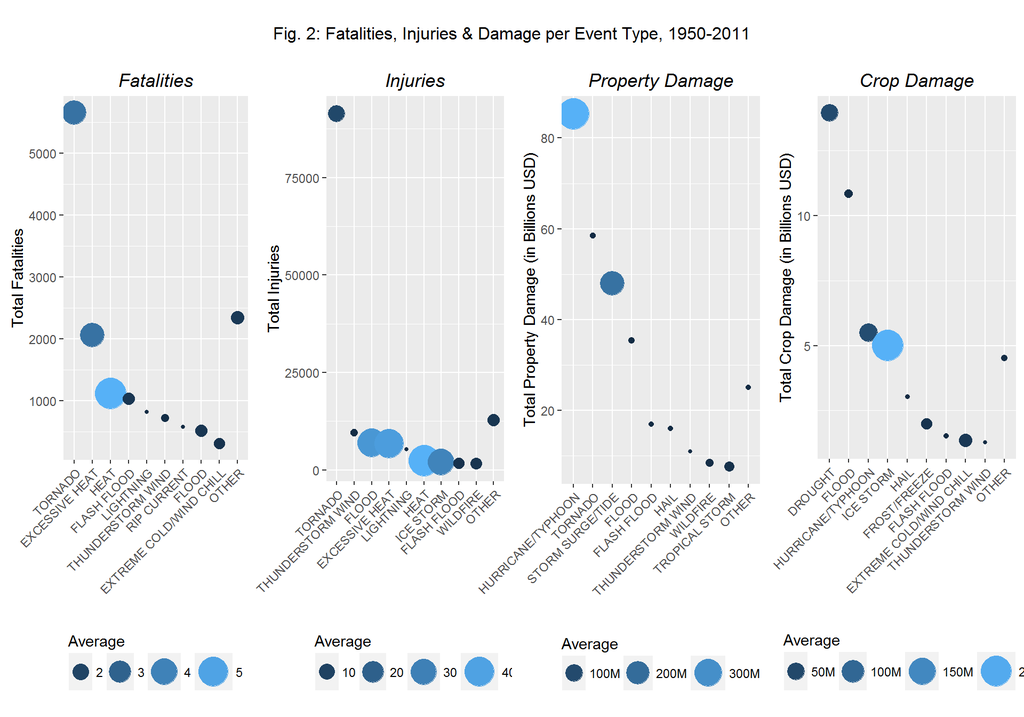

```r
multiplot (p1,p2,p3,p4, cols=4, title="Fig. 2: Fatalities, Injuries & Damage per Event Type, 1950-2011")
```

*Note: averages are calculated as total / number of events with paramater > 0.*

The discrepancies between total and average are explained by the fact that some events are much more likely to accur than others.

Final comments:

- Averages could have been calculated as total / number of events, but it is not clear what triggers a report for events without damage nor casualties. It seems that thunderstorms are reported much more frequently than other events (maybe because they are easier to spot ?) so such a ratio could induce a bias.
- Some event types in “OTHER” may have an average higher than the top10, but overall they have a much smaller impact. So it seemed relevant no to highlight them

# Appendix

We see a sharp increase in reported events starting in the 90’s:

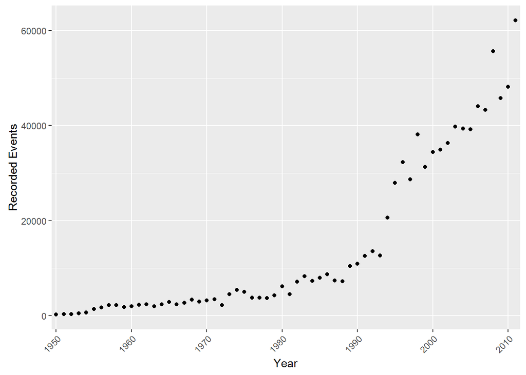

```r
# creating year variable from dates
p1 = ggplot(data.frame(table (storm$year)), aes(x=Var1, y=Freq, group = 1)) + geom_point()
p1 = p1 + theme(axis.text.x = element_text(angle = 45, vjust = 1, hjust=1))
p1 = p1 + scale_x_discrete(breaks = seq(1950, 2010, 10)) + xlab("Year") + ylab("Recorded Events")
p1
```

Here is the mapping of all the events to the 48 event types:

```r
pandoc.table(arrange(EVTYPE_list, Event_Type))
```

| EVTYPE | Event_Type |
| --- | --- |
| ASTRONOMICAL LOW TIDE | ASTRONOMICAL LOW TIDE |
| AVALANCE | AVALANCHE |
| AVALANCHE | AVALANCHE |
| HEAVY SNOW/BLIZZARD/AVALANCHE | AVALANCHE |
| BLIZZARD | BLIZZARD |
| BLIZZARD/WINTER STORM | BLIZZARD |
| GROUND BLIZZARD | BLIZZARD |
| HEAVY SNOW/BLIZZARD | BLIZZARD |
| HIGH WIND/BLIZZARD | BLIZZARD |
| COASTAL FLOODING/EROSION | COASTAL FLOOD |
| COASTAL FLOOD | COASTAL FLOOD |
| COASTAL FLOODING | COASTAL FLOOD |
| COASTAL FLOODING/EROSION | COASTAL FLOOD |
| HEAVY SURF COASTAL FLOODING | COASTAL FLOOD |
| HIGH WINDS/COASTAL FLOOD | COASTAL FLOOD |
| COLD | COLD/WIND CHILL |
| COLD AND SNOW | COLD/WIND CHILL |
| COLD AND WET CONDITIONS | COLD/WIND CHILL |
| COLD TEMPERATURE | COLD/WIND CHILL |
| COLD WAVE | COLD/WIND CHILL |
| COLD WEATHER | COLD/WIND CHILL |
| COLD/WIND CHILL | COLD/WIND CHILL |
| COLD/WINDS | COLD/WIND CHILL |
| EXTENDED COLD | COLD/WIND CHILL |
| FOG AND COLD TEMPERATURES | COLD/WIND CHILL |
| HIGH WINDS/COLD | COLD/WIND CHILL |
| LOW TEMPERATURE | COLD/WIND CHILL |
| SNOW/ BITTER COLD | COLD/WIND CHILL |
| SNOW/COLD | COLD/WIND CHILL |
| DENSE FOG | DENSE FOG |

[output cut: 412 more lines]

Here is the code used for the mapping (decode.R; ; [source: r-bloggers](http://www.r-bloggers.com/search-and-replace-are-you-tired-of-nested-ifelse/))):

```r
# one to one decode function
decode <- function(x, search, replace, default = NULL) {

  # build a nested ifelse function by recursion
  decode.fun <- function(search, replace, default = NULL) {

    # replace all remaining x values by the default value (or x if not specified)
    if (length(search) == 0) {
      function(x) if (is.null(default)) x else rep(default, length(x))
    }

    # recursive function
    else {

      function(x) {
        ifelse(x == search[1], replace[1],
                    decode.fun(tail(search, -1), tail(replace, -1), default)(x)) # recursive call
      }
    }

  }

  return(decode.fun(search, replace, default)(x))

}

# many to one decode function
decodeList <- function(x, default = NULL, searchNreplace) {

  # split vector in two
  search <- searchNreplace[seq(1, length(searchNreplace), 2)]
  replace <- searchNreplace[seq(2, length(searchNreplace), 2)]

  # build a nested ifelse function by recursion
  decode.fun <- function(search, replace, default = NULL) {

    # replace all remaining x values by the default value (or x if not specified)
    if (length(search) == 0) {
      function(x) if (is.null(default)) x else rep(default, length(x))
    }

    # recursive function
    else {

      function(x) {
        ifelse(apply(sapply(search[[1]], grepl, x),1,any), replace[[1]],
               decode.fun(tail(search, -1), tail(replace, -1), default)(x)) # recursive call
      }
    }

  }

  return(decode.fun(search, replace, default)(x))

}

# source: http://www.r-bloggers.com/search-and-replace-are-you-tired-of-nested-ifelse/
```

Here is the code use for multiplotting (multiplot.R; source: cookbook-R):

```r
# Multiple plot function
#
# ggplot objects can be passed in ..., or to plotlist (as a list of ggplot objects)
# - cols:   Number of columns in layout
# - layout: A matrix specifying the layout. If present, 'cols' is ignored.
#
# If the layout is something like matrix(c(1,2,3,3), nrow=2, byrow=TRUE),
# then plot 1 will go in the upper left, 2 will go in the upper right, and
# 3 will go all the way across the bottom.

multiplot <- function(..., plotlist=NULL, file, cols=1, layout=NULL, title=NULL) {
  library(grid)

  # Make a list from the ... arguments and plotlist
  plots <- c(list(...), plotlist)

  numPlots = length(plots)

  # If layout is NULL, then use 'cols' to determine layout
  if (is.null(layout)) {
    # Make the panel
    # ncol: Number of columns of plots
    # nrow: Number of rows needed, calculated from # of cols
    layout <- matrix(seq(1, cols * ceiling(numPlots/cols)),
                     ncol = cols, nrow = ceiling(numPlots/cols))
  }

  # all rows have the same height
  layoutHeights <- rep(1, nrow(layout))

  # if title, we add a first row & fix it to 1/4 of the other heigths
  if (!is.null(title)) {
    layout <- rbind(rep(0, ncol(layout)), layout)
    layoutHeights <- c(0.1 * sum(layoutHeights), layoutHeights)
  }

  #if (numPlots==1) {
  #  print(plots[[1]])
  #}
  #else {

    # Set up the page
    grid.newpage()
    pushViewport(viewport(layout = grid.layout(nrow(layout), ncol(layout), heights = (unit(layoutHeights, "null")))))

    #title
    if (!is.null(title)) {
      matchidx <- as.data.frame(which(layout == 0, arr.ind = TRUE))
      grid.text(title, vp = viewport(layout.pos.row = matchidx$row,
                                     layout.pos.col = matchidx$col))
    }

    # Make each plot, in the correct location
    for (i in 1:numPlots) {
      # Get the i,j matrix positions of the regions that contain this subplot
      matchidx <- as.data.frame(which(layout == i, arr.ind = TRUE))

      print(plots[[i]], vp = viewport(layout.pos.row = matchidx$row,
                                      layout.pos.col = matchidx$col))
    }

  #}
}
```